# 検索技術レポート

20X3124 中津颯太

# 1. 目的

データの分析に対する実験及びその結果に対する考察を行うことを目的とする。今回はMNISTを用いて手書き数字のデータセットをダウンロードし、CNNを用いて画像データの分類を行うことによって得られる結果について考察する。

# 2. 実験に使用するもの

データ…MNIST  
分析手法…CNN

# 3. 実験に使用するコード

セットアップ  
実験に必要なライブラリのインポートを行う。

```python
import numpy as np
from tensorflow import keras
from tensorflow.keras import layers
import matplotlib.pyplot as plt
```

MNISTからデータを取得する。ここで、_trainは学習用データ、_testは性能を評価するためのデータである。

```python
def get_data_mnist(data_size=None):
    (X_train, y_train), (X_test, y_test) = keras.datasets.mnist.load_data()
    X_train = X_train.astype(np.float32) / 255.0
    X_test = X_test.astype(np.float32) / 255.0
    X_train = np.expand_dims(X_train, -1)
    X_test = np.expand_dims(X_test, -1)
    if data_size is not None:
        X_train = X_train[:data_size]
        y_train = y_train[:data_size]
    return (X_train, y_train), (X_test, y_test)
```

```python
(X_train, y_train), (X_test, y_test) = get_data_mnist()
print(f"X_train shape : {X_train.shape} ")
print(f"X_test shape  : {X_test.shape} ")
print(f"y_train shape : {y_train.shape} ")
print(f"y_test shape  : {y_test.shape} ")
```

```
X_train shape : (60000, 28, 28, 1)
X_test shape  : (10000, 28, 28, 1)
y_train shape : (60000,)
y_test shape  : (10000,)
```

CNNモデルを構築

```python
model = keras.Sequential(
    [
        layers.InputLayer(input_shape=(28, 28, 1)),
        layers.Conv2D(32, kernel_size=(5, 5), activation="relu"),
        layers.MaxPooling2D(pool_size=(2, 2)),
        layers.Flatten(),
        layers.Dense(20, activation="relu"),
        layers.Dense(10, activation="softmax"),
    ]
)

model.summary()
```

```
Model: "sequential_1"
_________________________________________________________________
 Layer (type)                Output Shape              Param #
=================================================================
 conv2d_1 (Conv2D)           (None, 24, 24, 32)        832

 max_pooling2d_1 (MaxPooling  (None, 12, 12, 32)       0
 2D)

 flatten_1 (Flatten)         (None, 4608)              0

 dense_2 (Dense)             (None, 20)                92180

 dense_3 (Dense)             (None, 10)                210

=================================================================
Total params: 93,222
Trainable params: 93,222
Non-trainable params: 0
_________________________________________________________________
```

誤差関数と最適化手法を行うモデルの定義と、セットアップを行う。

```python
def model_setup(model, optimizer="adam", lr=0.001):
    if optimizer == "adam":
        optim = keras.optimizers.Adam(learning_rate=lr)
    elif optimizer == "sgd":
        optim = keras.optimizers.SGD(learning_rate=lr)
    else:
        raise ValueError
    model.compile(
        loss="sparse_categorical_crossentropy", optimizer=optim, metrics=["accuracy"]
    )
```

```python
model_setup(model)
```

CNNでの学習前における誤差、正解率を調べておく。

```python
loss_no_train, accuracy_no_train = model.evaluate(X_test, y_test, verbose=0)
print("学習前の誤差 : ", loss_no_train)
print("学習前の正解率 : ", accuracy_no_train)
```

```
学習前の誤差 :  2.29536509513855
学習前の正解率 :  0.12020000070333481
```

学習前の段階でそのような数字を間違えているのかの確認を行う。

```python
def random_plot(X, y, predict=None):
    W = 10
    H = 5
    fig = plt.figure(figsize=(10, 20))
    fig.subplots_adjust(left=0, right=1, bottom=0, top=0.3, hspace=0.10, wspace=0.10)
    for i in range(5):
        for j in range(10):
            x_tmp = X[y == j]
            idx = np.random.randint(len(x_tmp))
            x = x_tmp[idx].reshape(28, 28)
            ax = fig.add_subplot(H, W, (i * 10) + j + 1, xticks=[], yticks=[])
            ax.imshow(x, cmap="gray")
            if predict is not None:
                pred_tmp = predict[y == j]
                p = pred_tmp[idx]
                ax.set_title(f"{j} -> {p}")
            else:
                ax.set_title(f"label : {j}")
```

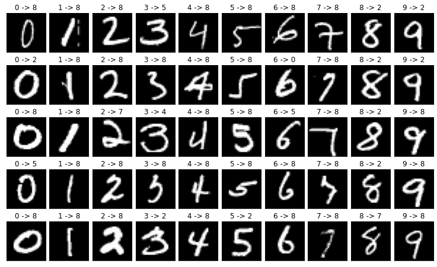

```python
test_predict = np.argmax(model.predict(X_test), 1)
false_idx = y_test != test_predict
random_plot(X_test[false_idx], y_test[false_idx], test_predict[false_idx])
```

CNNモデルでの学習を行う。

```python
batch_size = 128
epochs = 10
trainlog = model.fit(
    X_train, y_train, batch_size=batch_size, epochs=epochs, validation_split=0.1
)
```

学習後の正解率を確認する。

```python
loss_train, accuracy_train = model.evaluate(X_test, y_test, verbose=0)
print(f"学習後の誤差 :  ", loss_train)
print(f"学習後の正解率 : ", accuracy_train)
```

```
学習後の誤差 :   0.045140840113162994
学習後の正解率 :  0.9873999953269958
```

学習後はどのような数字で予測を間違えているのかの確認を行う。

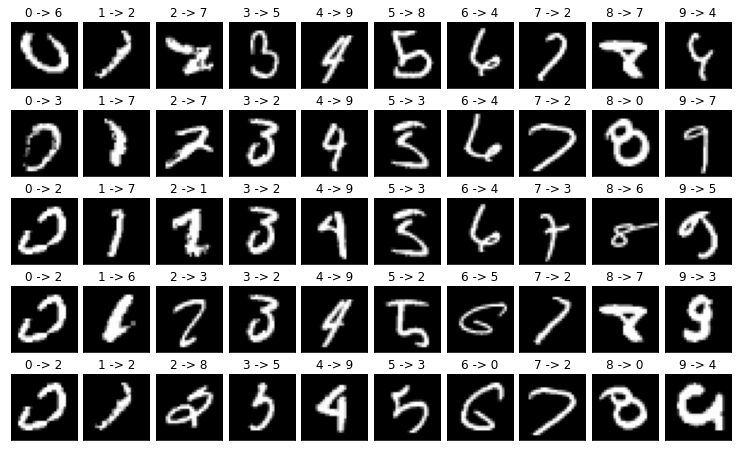

```python
test_predict = np.argmax(model.predict(X_test), 1)
false_idx = y_test != test_predict
random_plot(X_test[false_idx], y_test[false_idx], test_predict[false_idx])
```

最後に学習前と後での正解率、誤差を比較すると、以下のようになっている。  
学習前の誤差 : 2.29536509513855  
学習後の誤差 : 0.045140840113162994  
学習前の正解率 : 0.12020000070333481  
学習後の正解率 : 0.9873999953269958

# 4. 考察

今回MNISTのデータをCNNを通して分類を行ったが、学習前と後の比較をすると、学習後は誤差、正解率共に大きく改善されていることが分かる。また、予測を間違えた文字についても学習前と後で比較すると、学習後に予測を間違えた画像は手書きの文字として歪んだ形となっており、より識別が難しそうなものと見受けられる。学習後の正解率はおよそ98%ほどであるが、より改善するためにはッチサイズやエポック数を変更することで向上が見込めると思われる。ただし、大きくしすぎると過学習になるため大きさの変更は大きくすればよいとも言えないと思われる。

# 5. まとめ

今回はMNISTのデータを用いることでデータの分類(今回は手書きの数字)分けを行った。CNNで学習した結果かなり正確に数字の分類分けをすることができたことがわかった。

# 6. 参考文献

COD EXA https://www.codexa.net/cnn-mnist-keras-beginner/